# Predicting the Manner of Barbell Lift Executions

Lilyana T. Mladenova

December 14, 2016

## II. Loading Dependacies

```r
library(knitr)
library(caret)
library(e1071)
library(randomForest)
library(xgboost)
library(plyr)
library(dplyr)
library(reshape2)
library(corrplot)
library(parallel)
library(doParallel)
```

## III. Loading and Pre-Processing Data

### III.1. Loading Data

```r
#setwd(./data)
if(!file.exists("data")){
        dir.create("data")
}

train.fileURL <-"https://d396qusza40orc.cloudfront.net/predmachlearn/pml-training.csv"
test.fileURL <-"https://d396qusza40orc.cloudfront.net/predmachlearn/pml-testing.csv"
download.file(train.fileURL, destfile = "./data/pml-training.csv")
download.file(test.fileURL, destfile = "./data/pml-testing.csv")
tr <- read.csv("./data/pml-training.csv")
tes <- read.csv("./data/pml-testing.csv")
```

### III.2. Cleaning Data

- The features, which name consists an element of a descriptive statistic (e.g., skewness, kurtosis) will be removed from the data sets. These features appeared to have predominantly missing values.
- The first 7 features will also be removed as they deemed to be not informative for the purpose of this analysis.

```r
nr <- grep("^kurtosis|skewness|min|max|avg|stddev|var|amplitude", names(tr))
training <- tr[, -c(1:7, nr)]
testing <- tes[, -c(1:7, nr)]
rm("tes", "tr") #declatering the workspace
dim(training)
```

```
## [1] 19622    53
```

After cleaning the data, 52 features and the dependent variable “classe” remained.

### III.3.Splitting the training data into trTraining and trTesting data

```r
set.seed(1234)
inTrain <- createDataPartition(y=training$classe, p = 0.75, list = FALSE)
trTraining <- training[inTrain, ]
trTesting <- training[-inTrain, ]
rm("training")
```

## IV. Exploratory Data Analysis

None of the features has missing values, nor near-zero variance.

```r
sum(sapply(trTraining, function(x) sum(is.na(x)))) # checking for missing values
```

```
## [1] 0
```

```r
sum(nearZeroVar(trTraining)) # checking for near-zero variance variables
```

```
## [1] 0
```

Table 1 presents the results from the descriptive analysis of the data (i.e., mean, variance, skewness, kurtosis).

```r
ea.df <- tbl_df(trTraining[, -53]) %>%
        mutate(index = 1:14718) %>%
        melt(id.vars = trTraining$index) %>%
        filter(variable %in% names(trTraining[, -53])) %>%
        group_by(variable) %>%
        dplyr:::summarize(mean = round(mean(value), 4),
                variance = round(var(value), 4),
                skewness = round(skewness(value), 4),
                kurtosis = round(kurtosis(value), 4)) %>%
        as.data.frame

kable(ea.df, caption = "Table 1. Descriptive Statistics")
```

Table 1. Descriptive Statistics

| variable | mean | variance | skewness | kurtosis |
| --- | --- | --- | --- | --- |
| roll_belt | 64.5772 | 3939.1027 | -0.0214 | -1.9314 |
| pitch_belt | 0.1437 | 502.5599 | -0.9945 | -0.1349 |
| yaw_belt | -10.6603 | 9140.2759 | 0.8955 | -0.6114 |
| total_accel_belt | 11.3318 | 59.8873 | 0.0307 | -1.7521 |
| gyros_belt_x | -0.0055 | 0.0429 | -0.5651 | 6.9824 |
| gyros_belt_y | 0.0400 | 0.0060 | -0.0059 | 4.4882 |
| gyros_belt_z | -0.1293 | 0.0581 | 0.2222 | 6.3026 |
| accel_belt_x | -5.4030 | 879.0436 | 0.9656 | -0.1398 |
| accel_belt_y | 30.1518 | 812.8937 | 0.1438 | -1.6091 |
| accel_belt_z | -72.8053 | 10098.8424 | 0.0249 | -1.8331 |
| magnet_belt_x | 55.9365 | 4133.8915 | 1.4098 | 1.9887 |
| magnet_belt_y | 593.6681 | 1273.9432 | -2.2308 | 7.9200 |
| magnet_belt_z | -345.6851 | 4171.6423 | -0.0278 | 10.9973 |
| roll_arm | 18.0837 | 5297.0680 | -0.1769 | -0.4034 |
| pitch_arm | -4.4951 | 940.3171 | 0.1954 | 0.2789 |
| yaw_arm | -0.7604 | 5090.9025 | -0.0863 | -0.1351 |
| total_accel_arm | 25.5217 | 111.3786 | 0.0854 | -0.2535 |
| gyros_arm_x | 0.0428 | 3.9755 | -0.2859 | -0.4373 |
| gyros_arm_y | -0.2557 | 0.7263 | 0.1534 | 0.6776 |
| gyros_arm_z | 0.2713 | 0.3030 | -0.1768 | 0.0370 |
| accel_arm_x | -59.7151 | 33065.7965 | 0.3403 | -0.7824 |
| accel_arm_y | 32.3524 | 12055.9972 | 0.1066 | -1.0278 |
| accel_arm_z | -71.2532 | 18421.4757 | -0.8728 | 0.9084 |
| magnet_arm_x | 193.2864 | 195423.5398 | -0.1602 | -1.5962 |
| magnet_arm_y | 156.1275 | 40746.9433 | -0.4651 | -0.8249 |
| magnet_arm_z | 305.8285 | 107543.9357 | -1.1398 | 0.0898 |
| roll_dumbbell | 23.3507 | 4931.3691 | -0.7377 | -0.4603 |
| pitch_dumbbell | -10.9101 | 1370.2208 | 0.5216 | -0.1456 |
| yaw_dumbbell | 1.0611 | 6782.6726 | 0.2254 | -1.4194 |
| total_accel_dumbbell | 13.7114 | 104.3120 | 0.5941 | -0.8240 |
| gyros_dumbbell_x | 0.1579 | 2.9854 | -112.0825 | 13240.9937 |
| gyros_dumbbell_y | 0.0453 | 0.4174 | 35.4626 | 2840.9725 |
| gyros_dumbbell_z | -0.1234 | 6.9372 | 118.5934 | 14276.1279 |
| accel_dumbbell_x | -28.5694 | 4509.6281 | -0.4582 | 1.1098 |
| accel_dumbbell_y | 52.5356 | 6550.1582 | 0.3568 | -0.4263 |
| accel_dumbbell_z | -38.8312 | 11893.2135 | -0.1070 | -0.5724 |
| magnet_dumbbell_x | -328.8062 | 115294.4433 | 1.6960 | 1.4530 |
| magnet_dumbbell_y | 220.8283 | 106746.0047 | -1.8340 | 3.0934 |
| magnet_dumbbell_z | 46.7333 | 19663.9134 | 0.8733 | 0.2568 |
| roll_forearm | 34.5703 | 11632.5155 | -0.4695 | -0.7448 |
| pitch_forearm | 10.8009 | 787.4037 | -0.5046 | 0.8905 |
| yaw_forearm | 19.1069 | 10562.4663 | -0.2639 | -1.1334 |
| total_accel_forearm | 34.7019 | 100.8617 | -0.5760 | 1.0887 |
| gyros_forearm_x | 0.1584 | 0.4304 | -2.4976 | 88.7700 |
| gyros_forearm_y | 0.0773 | 11.2661 | 53.9548 | 5000.2384 |
| gyros_forearm_z | 0.1554 | 3.9794 | 105.2855 | 12181.2041 |
| accel_forearm_x | -61.7054 | 32639.9197 | -0.2308 | -0.6980 |
| accel_forearm_y | 163.9539 | 39864.2330 | -0.6483 | -0.1220 |
| accel_forearm_z | -54.4848 | 19169.9958 | 0.4263 | -0.9162 |
| magnet_forearm_x | -311.6286 | 121441.0358 | 0.6492 | -0.0748 |
| magnet_forearm_y | 378.4543 | 260030.0779 | -0.7407 | -0.4606 |
| magnet_forearm_z | 392.7697 | 136344.4454 | -1.2182 | 0.8944 |

To comprehend better the results for the distribution of the data, Figure 1 visually presents the level of skewness of the features. It appears that the data points of 14 features are moderately skewed and 12 are highly skewed.

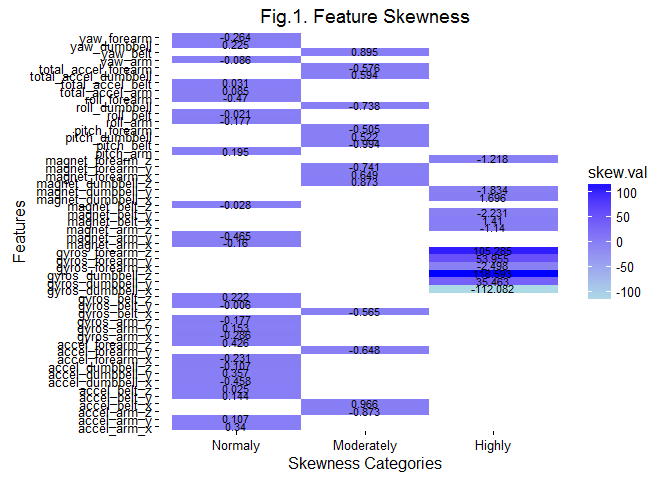

```r
skewness <- matrix(apply(trTraining[, -53], 2, skewness))
ea.df <- data.frame(cbind(names(trTraining[, -53]), skewness))
colnames(ea.df) <- c("feature", "skew.val")
ea.df$skew.val <- as.numeric(as.character(ea.df$skew.val))
ea.df$skew.cat[ea.df$skew.val < -1 | ea.df$skew.val > 1] <- "Highly"
ea.df$skew.cat[ea.df$skew.val >= -1 & ea.df$skew.val <= -0.5 | ea.df$skew.val >= 0.5 & ea.df$skew.val <= 1] <- "Moderately"
ea.df$skew.cat[ea.df$skew.val > -0.5 & ea.df$skew.val < 0.5] <- "Normaly"
ea.df$skew.cat <- factor(ea.df$skew.cat, levels = c("Normaly", "Moderately", "Highly"))
ggplot(ea.df, aes(x = skew.cat, y = feature, fill = skew.val)) +
        geom_tile(show.legend = TRUE) +
        theme_classic() +
        theme(axis.text.x = element_text(hjust = 0.5)) +
        scale_fill_gradient(low = "light blue", high = "blue") +
        geom_text(label = round(ea.df$skew.val,3), size = 3, vjust = 0.4) +
        labs(title = "Fig.1. Feature Skewness", x = "Skewness Categories", y = "Features")
```

Figure 2 visually presents the results from the correlation analysis of the features. It appears that there is substantial number of high between-predictor correlations.

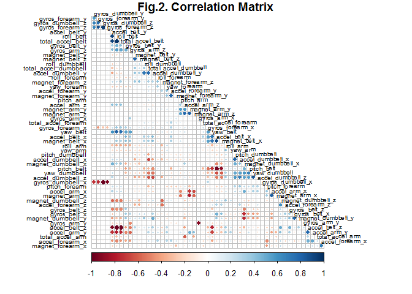

```r
correlations <- cor(trTraining[, -53])
corrplot(correlations, type = "lower",
         title = "Fig.2. Correlation Matrix",
         diag = FALSE,
         order = "hclust",
         hclust.method = "complete",
         tl.pos = "ld",
         tl.cex = 0.6,
         tl.col = "black",
         cl.pos = "b",
         tl.srt=1,
         mar = c(1, 1, 1, 1))
```

## V. Rationale

Given the multidimensionality of the data and the peculiarity of the predictors (i.e., moderately to highly skewed predictors and high between-predictor correlations), **Random Forest** and **Extreme Gradient Boosting** will be considered for building the predictive model. In general, ensemble learning methods are very accurate and effective in handling (1) multidimensional data, (2) large number of training examples, and (3) differing types of data (e.g., skewed data) without pre-processing. All of the features will be used in the modeling, as both algorithms have build-in feature selections when accessed with the **train** function of **caret**.

## VI. Using Cross Validation for Model Selection

10-fold cross validation repeated 3 times will be used to compare the models.

```r
cluster <- makeCluster(detectCores() - 1)
registerDoParallel(cluster)
metric <- "Accuracy"
control <- trainControl(method = "repeatedcv",
                        repeats = 3,
                        returnData = FALSE,
                        allowParallel = TRUE)
set.seed(123)
mod.rf <- train(classe ~., data = trTraining,
                method= "rf",
                metric = metric,
                trControl = control)

set.seed(123)
mod.xgb <- train(classe ~., data = trTraining,
                 method = "xgbTree",
                 metric = metric,
                 trControl = control)
stopCluster(cluster)
```

Figure 3 visually presents the results from the model comparison. It appears that *Extreme Gradient Boosting* algorithm produces more accurate model with an accuracy of 99.43% and **estimated out-of-sample error** of 0.57%.

```r
results <- resamples(list(RF = mod.rf, XGB = mod.xgb))
summary(results)
```

```
##
## Call:
## summary.resamples(object = results)
##
## Models: RF, XGB
## Number of resamples: 30
##
## Accuracy
##       Min. 1st Qu. Median   Mean 3rd Qu.   Max. NA's
## RF  0.9898  0.9912 0.9929 0.9927  0.9939 0.9959    0
## XGB 0.9912  0.9927 0.9946 0.9943  0.9952 0.9973    0
##
## Kappa
##       Min. 1st Qu. Median   Mean 3rd Qu.   Max. NA's
## RF  0.9871  0.9888 0.9910 0.9908  0.9923 0.9948    0
## XGB 0.9888  0.9908 0.9931 0.9928  0.9940 0.9966    0
```

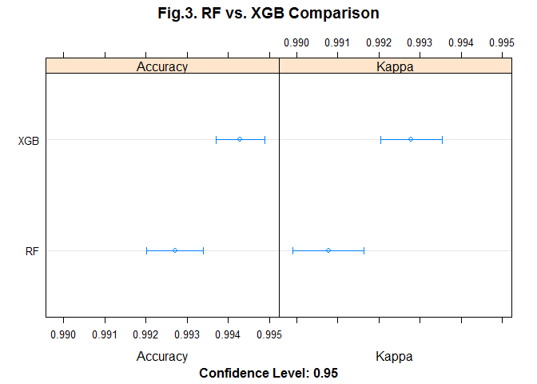

```r
dotplot(results, main = "Fig.3. RF vs. XGB Comparison")
```

The hypothesis testing for the difference between the model performances reveals that the difference in the accuracy of 0.001585 is statistically significant, p < 0.001

```r
modelDiff <- diff(results)
summary(modelDiff)
```

```
##
## Call:
## summary.diff.resamples(object = modelDiff)
##
## p-value adjustment: bonferroni
## Upper diagonal: estimates of the difference
## Lower diagonal: p-value for H0: difference = 0
##
## Accuracy
##     RF        XGB
## RF            -0.001585
## XGB 2.121e-05
##
## Kappa
##     RF        XGB
## RF            -0.002006
## XGB 2.108e-05
```

To follow are the tuning parameters of the “optimal model” (among the default values), they will be used as reference values for subsequent tuning the model.

```r
mod.xgb$bestTune
```

```
##     nrounds max_depth eta gamma colsample_bytree min_child_weight
## 102     150         3 0.4     0              0.8                1
##     subsample
## 102       0.5
```

The results revealed that the accuracy of the “optimal model” when predicting the **trTesting** data is 99.61% and *error rate of 0.39%*.

```r
cm_xgb <-confusionMatrix(predict(mod.xgb, trTesting[, -53]), trTesting$classe)
cm_xgb
```

```
## $positive
## NULL
##
## $table
##           Reference
## Prediction    A    B    C    D    E
##          A 1395    0    0    0    0
##          B    0  947    8    0    1
##          C    0    2  844    4    0
##          D    0    0    3  800    1
##          E    0    0    0    0  899
##
## $overall
##       Accuracy          Kappa  AccuracyLower  AccuracyUpper   AccuracyNull
##      0.9961256      0.9950993      0.9939562      0.9976658      0.2844617
## AccuracyPValue  McnemarPValue
##      0.0000000            NaN
##
## $byClass
##          Sensitivity Specificity Pos Pred Value Neg Pred Value Precision
## Class: A   1.0000000   1.0000000      1.0000000      1.0000000 1.0000000
## Class: B   0.9978925   0.9977244      0.9905858      0.9994934 0.9905858
## Class: C   0.9871345   0.9985182      0.9929412      0.9972866 0.9929412
## Class: D   0.9950249   0.9990244      0.9950249      0.9990244 0.9950249
## Class: E   0.9977802   1.0000000      1.0000000      0.9995006 1.0000000
##             Recall        F1 Prevalence Detection Rate
## Class: A 1.0000000 1.0000000  0.2844617      0.2844617
## Class: B 0.9978925 0.9942257  0.1935155      0.1931077
## Class: C 0.9871345 0.9900293  0.1743475      0.1721044
## Class: D 0.9950249 0.9950249  0.1639478      0.1631321
## Class: E 0.9977802 0.9988889  0.1837276      0.1833197
##          Detection Prevalence Balanced Accuracy
## Class: A            0.2844617         1.0000000
## Class: B            0.1949429         0.9978085
## Class: C            0.1733279         0.9928263
## Class: D            0.1639478         0.9970246
## Class: E            0.1833197         0.9988901
##
## $mode
## [1] "sens_spec"
##
## $dots
## list()
##
## attr(,"class")
## [1] "confusionMatrix"
```

```r
error <- (1 - cm_xgb$overall[[1]])*100
error
```

```
## [1] 0.3874388
```

## VII. Using Cross Validation for Tuning the Model

10-fold cross validation repeated once will be used to tune the xgb-model. A grid of tree values for each of the tuning parameters: **nrounds**, **max_depth**, **eta** and **gamma** will be created while holding *colsample_bytree*, *min_child_weight*, and *subsample* constant at their respective values from the initial training of the model.

```r
cluster <- makeCluster(detectCores() - 1)
registerDoParallel(cluster)
metric <- "Accuracy"
control_tune <- trainControl(method = "repeatedcv",
                        repeats = 1,
                        returnData = FALSE,
                        allowParallel = TRUE)

xgb_tuning <- expand.grid(nrounds = c(100, 150, 200),
                        max_depth = c(3, 4, 5),
                        eta = c(0.01, 0.1, 0.4),
                        gamma = c(0, 1, 2),
                        colsample_bytree = 0.8,
                        min_child_weight = 1,
                        subsample = 0.5

                        )

set.seed(123)
mod.xgb_tuned <- train(classe ~., data = trTraining,
                 method = "xgbTree",
                 metric = metric,
                 trControl = control_tune,
                 tuneGrid = xgb_tuning)
stopCluster(cluster)
```

```r
mod.xgb_tuned$bestTune
```

```
##    nrounds max_depth eta gamma colsample_bytree min_child_weight subsample
## 66     200         4 0.4     0              0.8                1       0.5
```

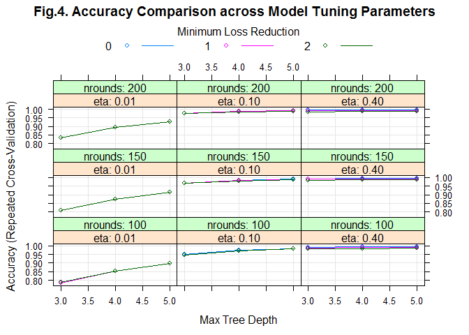

```r
plot(mod.xgb_tuned, main = "Fig.4. Accuracy Comparison across Model Tuning Parameters")
```

```r
cm_xgb_tuned <- confusionMatrix(predict(mod.xgb_tuned, trTraining[, -53]), trTraining$classe)
cm_xgb_tuned
```

```
## $positive
## NULL
##
## $table
##           Reference
## Prediction    A    B    C    D    E
##          A 4185    0    0    0    0
##          B    0 2848    0    0    0
##          C    0    0 2567    0    0
##          D    0    0    0 2412    0
##          E    0    0    0    0 2706
##
## $overall
##       Accuracy          Kappa  AccuracyLower  AccuracyUpper   AccuracyNull
##      1.0000000      1.0000000      0.9997494      1.0000000      0.2843457
## AccuracyPValue  McnemarPValue
##      0.0000000            NaN
##
## $byClass
##          Sensitivity Specificity Pos Pred Value Neg Pred Value Precision
## Class: A           1           1              1              1         1
## Class: B           1           1              1              1         1
## Class: C           1           1              1              1         1
## Class: D           1           1              1              1         1
## Class: E           1           1              1              1         1
##          Recall F1 Prevalence Detection Rate Detection Prevalence
## Class: A      1  1  0.2843457      0.2843457            0.2843457
## Class: B      1  1  0.1935046      0.1935046            0.1935046
## Class: C      1  1  0.1744123      0.1744123            0.1744123
## Class: D      1  1  0.1638810      0.1638810            0.1638810
## Class: E      1  1  0.1838565      0.1838565            0.1838565
##          Balanced Accuracy
## Class: A                 1
## Class: B                 1
## Class: C                 1
## Class: D                 1
## Class: E                 1
##
## $mode
## [1] "sens_spec"
##
## $dots
## list()
##
## attr(,"class")
## [1] "confusionMatrix"
```

```r
error.tuned <- (1 - cm_xgb_tuned$overall[[1]])*100
error.tuned
```

```
## [1] 0
```

## VIII. Predicting the Testing Data

To follow are the predictions of the 20 cases of the original **testing** data.

```r
predict(mod.xgb_tuned, testing[, -53])
```

```
##  [1] B A B A A E D B A A B C B A E E A B B B
## Levels: A B C D E
```

References:

[1] https://topepo.github.io/caret/feature-selection-overview.html  
[2] Kuhn, M. & Johnson, K.(2013). Applied Predictive Modeling  
[3] https://github.com/lgreski/datasciencectacontent/blob/master/markdown/pml-randomForestPerformance.md